# Part II - (Investigation of the variables that affect the interest rate of the loan listing)

## by (Mhlengi Fakude)

## Investigation Overview

> Data stories are best shared with beutiful and interesting visuals. On this investigation I picked few relevent variables from a large dataset that can contribute significantly on the interest of a loan listing. The variables that I picked are :
- `BorrowerRate`
- `LoanOriginalAmount`
- `MonthlyLoanPayment`
- `StatedMonthlyIncome`
- `ProsperScore`
- `Term`
- `Occupation`
- `BorrowerState`
- `IsBorrowerHomeowner`

  > The main focus was to find the relationship between the variables of interest and the BorrowerRate,using various visualization.

> Based on the visuals found while exploring the relationship of the variables, we can say that:  
> The key takeaway is that BorrowerRate is negatively correlated with most of the choosen variables and lot of decisions can be made based on that fact but a little bit of effort towards exploration of the relationship between each independent variables can result in further more insights .

## Dataset Overview

> This Dataset contains the records of 15198 loans listings from Prosper, it has lot of releted variables including loan amount, borrower rate (or interest rate), current loan status, borrower state, and many others. This Data can be used to make lot of informed decisions and also finding interesting insights. The dictionary and dataset can be found [here](https://docs.google.com/spreadsheets/d/1gDyi_L4UvIrLTEC6Wri5nbaMmkGmLQBk-Yx3z0XDEtI/edit#gid=0) and [here](https://s3.amazonaws.com/udacity-hosted-downloads/ud651/prosperLoanData.csv) respectively.

## (Visualization 1)

- On the following Heatmap, the main aim is to observe the Correlation between the chosen numerical variables, the key point of focus is the strong negative correlation between the Prosper Score and the BorrowerRate.  
  As the prosperscore increases the Borrower Rate decreases and that make a little bit of sense,because these are people who are in good postion according to Prosper ,hence they posses lower risk so they will have lower interest rate than those who are rated lower.
- Another intersting result found on this visual is the strong positive correlation between LoanOriginalAmount and MonthlyLoanPayment. As expected people who borrow big amount of money are expected to pay a little bit big monthly repayments.

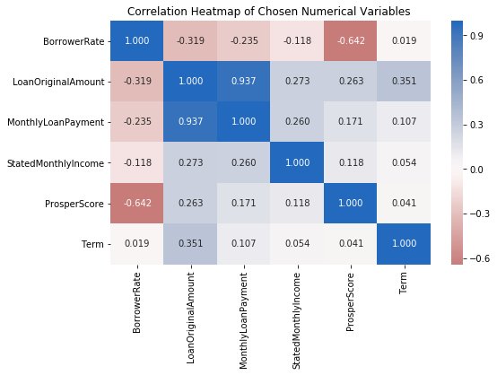

## (Visualization 2)

There are three different loan terms that each listing can take and interestingly the term associeted with the highest maximum BorrowerRate is the 36 months term.

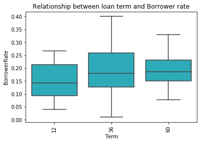

## (Visualization 3)

Below is the box plot representing the relationship and also the distribution between BorrowerRate and Prosper Score. We can clearly see that the minimum interest rate is found on the people with higher prosper score, as the higher score means that the person is in good financial standing and can be flagged as non risky client hence it makes a complete sense that those people be associeted with low interest rate on their listing.

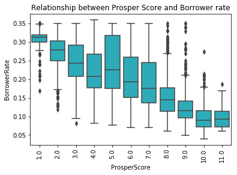